## Title: “Modeling Coral Invertebrate Communities Using 3D photogrammetry”

author: “Journ Galvan” date: “4/23/2020” output: html_document —

```r
knitr::opts_chunk$set(echo = TRUE)
```

```r
# Load libraries
library(here)
library(tidyverse)
library(vegan)
library(reshape)
library(ggplot2)
library(ggpubr)
library(zoo)
library(sjPlot)
library(sjmisc)
library(sjlabelled)
library(psych)
library(knitr)
library(faraway)
library(car)
library(MASS)
```

```r
#Load data
branch_width <- read.csv(here("photogrammetry_data/branchwidth_data.csv"))
coral_pg <- read.csv(here("photogrammetry_data/galvan_journ_datasheet_v2.csv"))
coral_field <- read.csv(here("photogrammetry_data/field_experiment_colony_measurements_moorea_summer2019.csv"))
cafi_surveys <- read.csv(here("cafi_data/revised_cafi_data_moorea_summer2019_11_27.csv"))
cafi_field <- read.csv(here("cafi_data/prelim_cafi_counts_moorea_summer2019.csv"))
updated_cafi <- read.csv(here("cafi_data/cafi_data_w_taxonomy_summer2019_2020_5_21.csv"))
```

```r
#Incorporate cleaned CAFI data
updated_cafi2 <- updated_cafi %>% filter(str_detect(coral_id, "^FE")) %>%
  dplyr::select(master_sort, coral_id, code, type, search_term, lowest_level, phylum, genus, species, general_notes) %>%
  subset(phylum!="Chordata")
```

```r
#Calculate CAFI richness, abundance, and diversity (shannon weiner) for each coral
cafi_summarized2 <- group_by(updated_cafi2, coral_id) %>%
  summarise(num_cafi = n(), cafi_richness = length(unique(code)), cafi_present = paste(sort(unique(code)), collapse = ";"))
cafi_summarized2$sw <- updated_cafi2 %>%
  count(code, coral_id = coral_id) %>%
  spread(code,n) %>%
  mutate_all(list(~tidyr::replace_na(.,0))) %>%
  dplyr::select(-coral_id) %>%
  diversity(index = "shannon")
```

```r
### Incorporate coral data

# Clean field data
coral_field2 <- coral_field %>%
  dplyr::rename(branch = branch_width)

# Clean photogrammetry morphometric data
coral_pg$volume_pg <- as.numeric(as.character(coral_pg$volume_pg)) # Convert factor to numeric

# Clean photogrammetry branch width data and take averages of branch distance for each coral
branch_width$branch_distance_mm <- as.numeric(as.character(branch_width$branch_distance_mm)) # Convert factor to numeric
branch_w_summarized <- group_by(branch_width, coral_id) %>%
  summarise(avg_w_cm = sum(branch_distance_mm/10)/n(), #take average branch distance and convert mm to cm
            measurements = length(unique(replicate_measurement)),
            locations = paste(sort(unique(location)), collapse = ";"))
```

```r
#Compare photogrammetry and manual measurements
coral_dim <- merge(coral_pg, branch_w_summarized, by = "coral_id") %>%
 merge(coral_field2, by = "coral_id") %>%
  mutate(volume_pg=volume_pg*10^6,
         max_hull_volume=max_hull_volume*10^6, #convert m^3 to cm^3
         surface_area=surface_area*10^4) #convert m^2 to cm^2

coral_dim$interstitial_space <- coral_dim$max_hull_volume - coral_dim$volume_pg #calculate available space by subtracting software estimated volume from convex hull volume

coral_dim <- coral_dim %>%
  dplyr::select(coral_id, branch, cafi, size_class, volume_field, volume_pg, surface_area, avg_w_cm, interstitial_space) %>%
  filter(cafi=="empty")

cafi_coral <- merge(cafi_summarized2, coral_dim, by ="coral_id") %>%
  drop_na(interstitial_space) %>%
  dplyr::select(coral_id, branch, cafi, size_class, volume_pg, surface_area, interstitial_space, volume_field, avg_w_cm, num_cafi, cafi_present, cafi_richness, sw)
```

```r
#Log transform variables
cafi_coral$log_num_cafi <- log(cafi_coral$num_cafi)
cafi_coral$log_volume_pg <- log(cafi_coral$volume_pg)
cafi_coral$log_interstitial_space <- log(cafi_coral$interstitial_space)
cafi_coral$log_surface_area <- log(cafi_coral$surface_area)
cafi_coral$log_cafi_richness <- log(cafi_coral$cafi_richness)

#Sqrt transform variables
cafi_coral$sqrt_num_cafi <- sqrt(cafi_coral$num_cafi)
cafi_coral$sqrt_volume_pg <- sqrt(cafi_coral$volume_pg)
cafi_coral$sqrt_interstitial_space <- sqrt(cafi_coral$interstitial_space)
cafi_coral$sqrt_surface_area <- sqrt(cafi_coral$surface_area)
cafi_coral$sqrt_cafi_richness <- sqrt(cafi_coral$cafi_richness)
```

### Correlating Morphological Measurements

##### We will first see if there is a mean difference between invertebrate abundance of both wide and tight corals

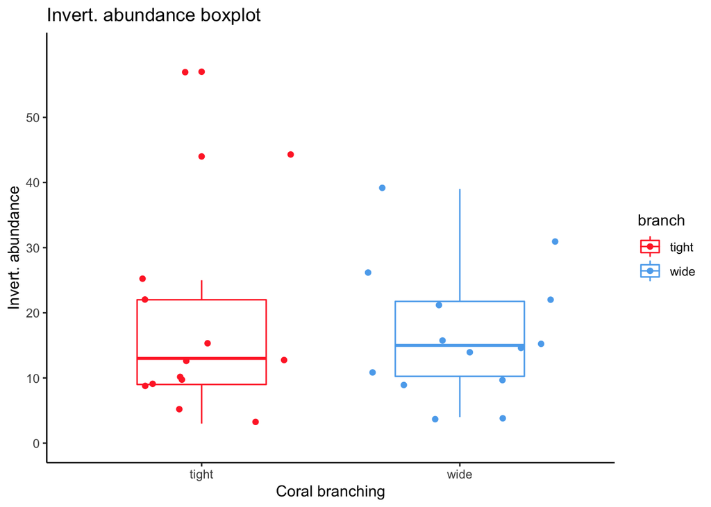

```r
# Boxplot of invert abundance
invert_box <- ggplot(cafi_coral, aes(x= branch, y=num_cafi, color = branch))+
  geom_boxplot(width = 0.5)+
  geom_jitter()+ # adds data on top of box plot
  scale_color_manual(values = c("firebrick1", "steelblue2"))+
  scale_y_continuous(limits= c(0, max(cafi_coral$num_cafi + 3)), breaks = c(0, 10, 20, 30, 40, 50))+
  theme_classic()+
  labs(y="Invert. abundance", x="Coral branching", title = "Invert. abundance boxplot")

invert_box
```

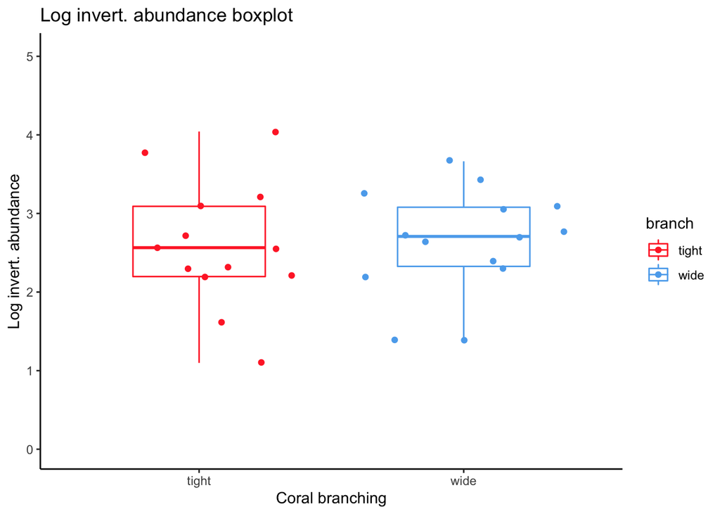

```r
log_invert_box <- ggplot(cafi_coral, aes(x= branch, y=log_num_cafi, color = branch))+
  geom_boxplot(width = 0.5)+
  geom_jitter()+ # adds data on top of box plot
  scale_color_manual(values = c("firebrick1", "steelblue2"))+
  scale_y_continuous(limits= c(0, max(cafi_coral$log_num_cafi + 1)))+
  theme_classic()+
  labs(y="Log invert. abundance", x="Coral branching", title = "Log invert. abundance boxplot")

log_invert_box
```

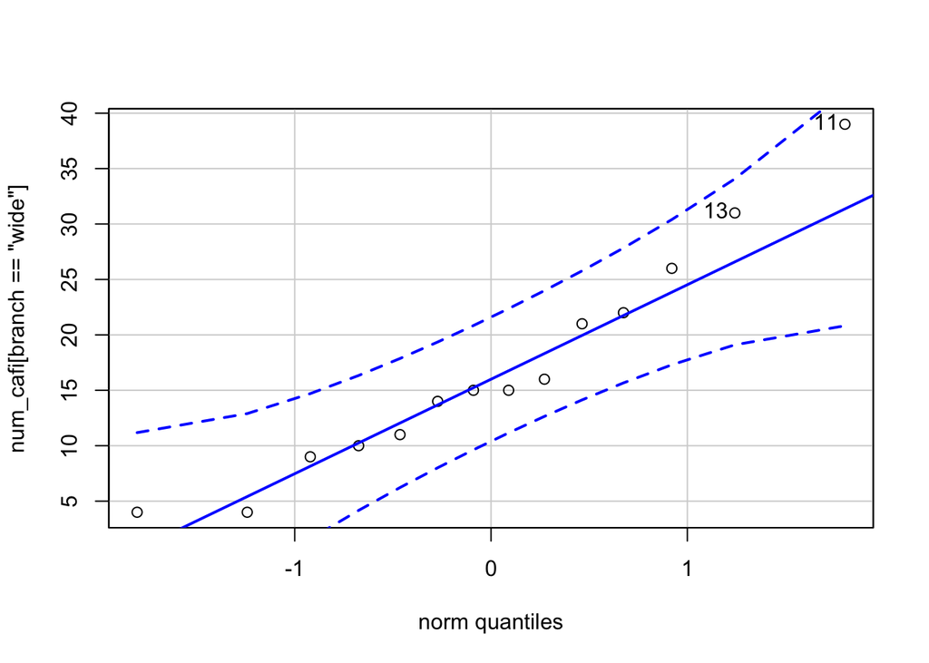

```
## [1] 11 13
```

```r
#Q-Q plot separated by group
with(cafi_coral, qqPlot(num_cafi[branch == "wide"], dist="norm"))
```

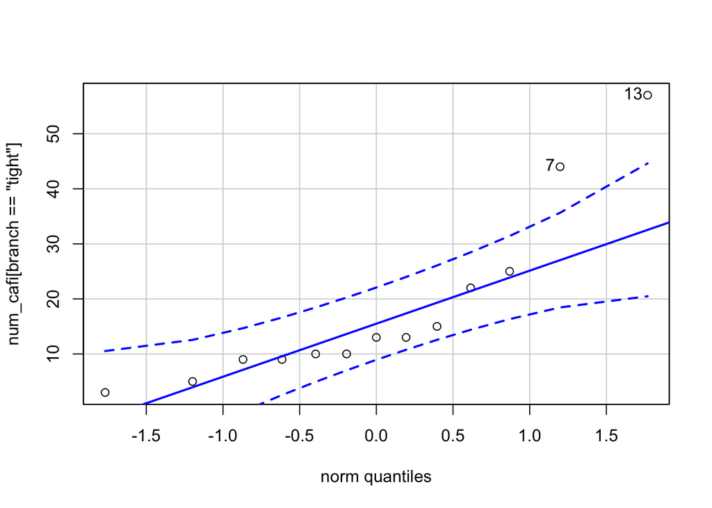

```
## [1] 13  7
```

```r
with(cafi_coral, qqPlot(num_cafi[branch == "tight"], dist="norm"))
```

```r
#Shapiro Wilk seperated by group
with(cafi_coral, shapiro.test(num_cafi[branch == "wide"]))
```

```
##
##  Shapiro-Wilk normality test
##
## data:  num_cafi[branch == "wide"]
## W = 0.94085, p-value = 0.4293
```

```r
with(cafi_coral, shapiro.test(num_cafi[branch == "tight"]))
```

```
##
##  Shapiro-Wilk normality test
##
## data:  num_cafi[branch == "tight"]
## W = 0.7891, p-value = 0.005074
```

With a $p>0.05$ we fail to reject the null hypothesis that our data is normally distributed for wide branching corals. With a $p<0.05$ we reject the null hypothesis that our data is normally distributed for tight branching corals. Because we are working with smaller data sets, we cannot use the central limit theorem.

```r
#Levene's test: response variable, group variable
leveneTest(cafi_coral$num_cafi, cafi_coral$branch)
```

```
## Levene's Test for Homogeneity of Variance (center = median)
##       Df F value Pr(>F)
## group  1  0.4456 0.5105
##       25
```

Because tight branching coral is not normally distributed, we could either perform a transformation or non-parametric test. We will try log transforming our data first. A column log transforming the number of inverts has already been created

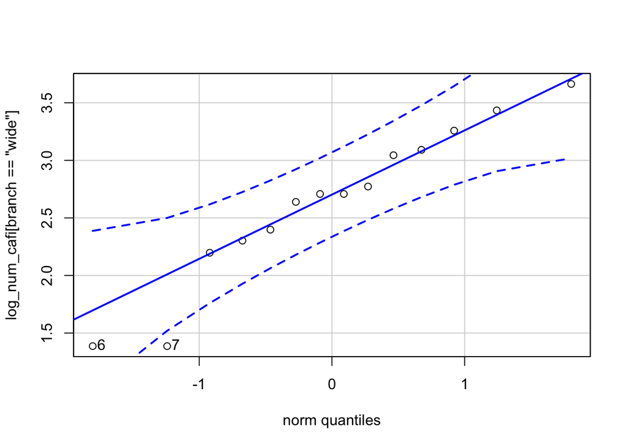

```
## [1] 6 7
```

```r
#Q-Q plot separated by group
with(cafi_coral, qqPlot(log_num_cafi[branch == "wide"], dist="norm"))
```

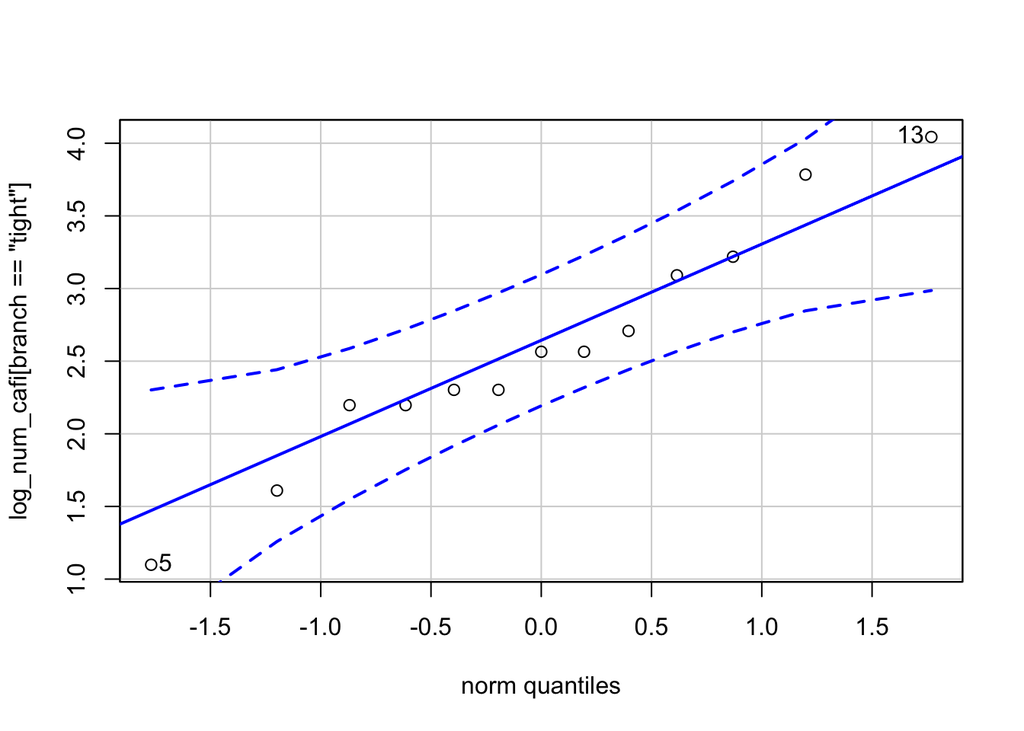

```
## [1]  5 13
```

```r
with(cafi_coral, qqPlot(log_num_cafi[branch == "tight"], dist="norm"))
```

```r
#Shapiro Wilk seperated by group
with(cafi_coral, shapiro.test(log_num_cafi[branch == "wide"]))
```

```
##
##  Shapiro-Wilk normality test
##
## data:  log_num_cafi[branch == "wide"]
## W = 0.94004, p-value = 0.4188
```

```r
with(cafi_coral, shapiro.test(log_num_cafi[branch == "tight"]))
```

```
##
##  Shapiro-Wilk normality test
##
## data:  log_num_cafi[branch == "tight"]
## W = 0.96842, p-value = 0.8748
```

```r
#Levene's test: response variable, group variable
leveneTest(cafi_coral$log_num_cafi, cafi_coral$branch)
```

```
## Levene's Test for Homogeneity of Variance (center = median)
##       Df F value Pr(>F)
## group  1  0.2629 0.6126
##       25
```

```r
# subset data
tight <- subset(cafi_coral, branch == "tight")
wide <- subset(cafi_coral, branch == "wide")

t.test(tight$log_num_cafi, wide$log_num_cafi, var.equal = TRUE)
```

```
##
##  Two Sample t-test
##
## data:  tight$log_num_cafi and wide$log_num_cafi
## t = -0.17843, df = 25, p-value = 0.8598
## alternative hypothesis: true difference in means is not equal to 0
## 95 percent confidence interval:
##  -0.6410008  0.5387880
## sample estimates:
## mean of x mean of y
##  2.590983  2.642089
```

With a $p>0.05$ we fail to reject the null hypothesis that the difference between the means of the log transformed invert counts are different from zero.

##### Since there does not appear to be a signficant difference in invertebrate counts between tight and wide corals, we will now test how well our software estimated method of calculating volume and interstitial space relates to invertebrate counts.

We will first assess $p<0.05$ to test if the linear regression slope was significantly different from zero. Correlation of dependent and independent variables $R^2$ was also included in the tables.

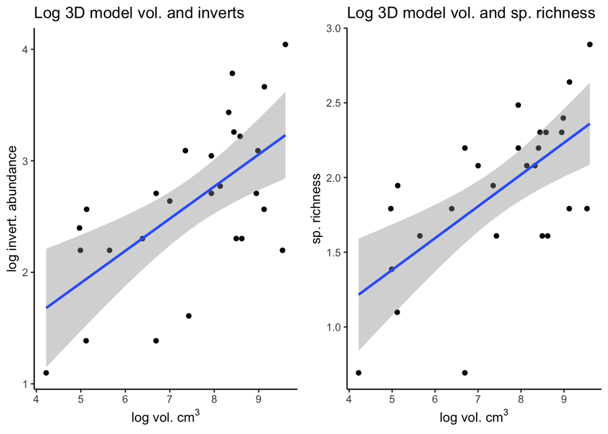

```r
#Create graphs of log transformed invertebrate abundance
log_cafi_vol <- ggplot(cafi_coral, aes(x=log_volume_pg, y=log_num_cafi))+
  geom_point()+
  geom_smooth(method = lm, se=TRUE)+
  theme_classic()+
  #facet_wrap(~branch)+
  labs(y="log invert. abundance", x= expression(paste("log vol. cm"^{3})), title = "Log 3D model vol. and inverts")

log_cafi_rich <- ggplot(cafi_coral, aes(x=log_volume_pg, y=log_cafi_richness))+
  geom_point()+
  geom_smooth(method = lm, se=TRUE)+
  theme_classic()+
  #facet_wrap(~branch)+
  labs(y="sp. richness", x= expression(paste("log vol. cm"^{3})), title = "Log 3D model vol. and sp. richness")

fig1 <- ggarrange(log_cafi_vol, log_cafi_rich,
                     ncol = 2, nrow = 1) #combines all graphs
fig1
```

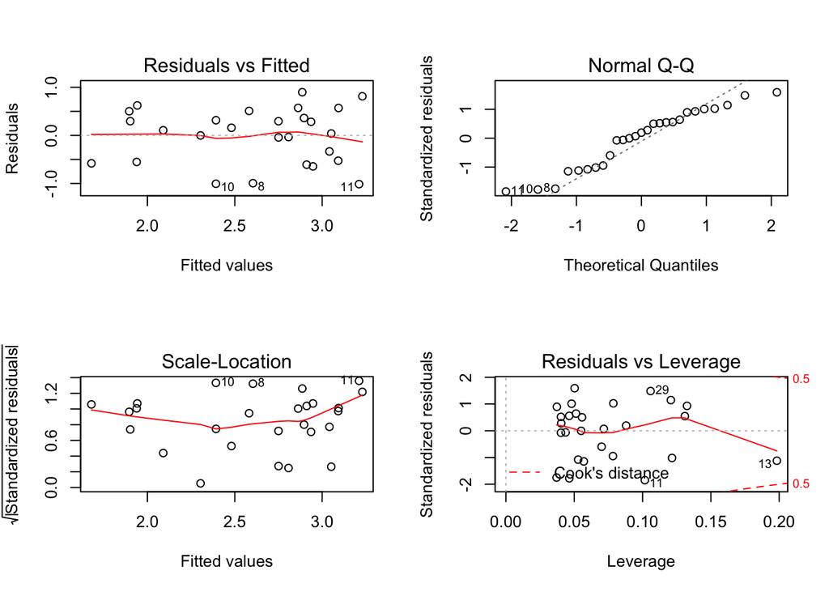

```r
#Residuals for log transformed data
log_lm_volume <- lm(log_num_cafi~log_volume_pg, data=cafi_coral)
par(mfrow=c(2,2))
plot(log_lm_volume)
```

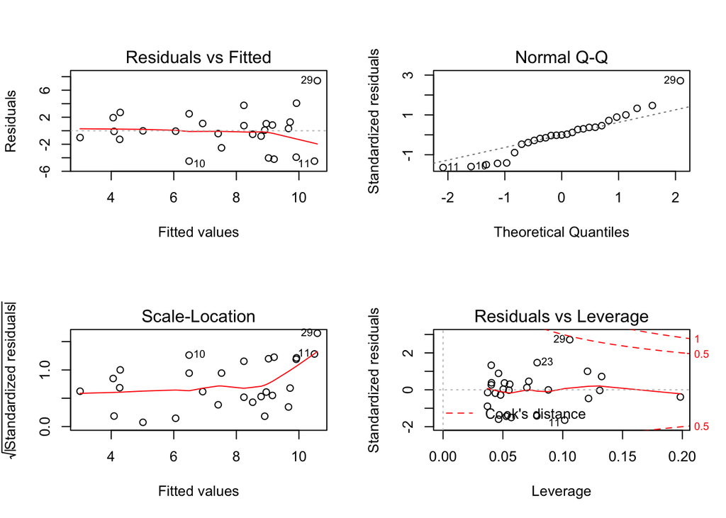

```r
par(mfrow=c(1,1))

log_lm_rich <- lm(cafi_richness~log_volume_pg, data=cafi_coral)
par(mfrow=c(2,2))
plot(log_lm_rich)
```

```r
par(mfrow=c(1,1))
```

```r
#HTML table from regression results
pl <- c(
  '(Intercept)' = "Intercept",
  log_volume_pg = "Log volume"
)
tab_model(log_lm_volume, log_lm_rich,
          pred.labels = pl,
          dv.labels = c("Log invertebrate abundance", "Species richness"))
```

|  | Log invertebrate abundance |  |  | Species richness |  |  |
| --- | --- | --- | --- | --- | --- | --- |
| Predictors | Estimates | CI | p | Estimates | CI | p |
| Intercept | 0.46 | -0.66 – 1.59 | 0.403 | -2.94 | -8.54 – 2.66 | 0.290 |
| Log volume | 0.29 | 0.14 – 0.44 | **<0.001** | 1.41 | 0.68 – 2.14 | **0.001** |
| Observations | 27 |  |  | 27 |  |  |
| R<sup>2</sup> / R<sup>2</sup> adjusted | 0.394 / 0.370 |  |  | 0.385 / 0.361 |  |  |

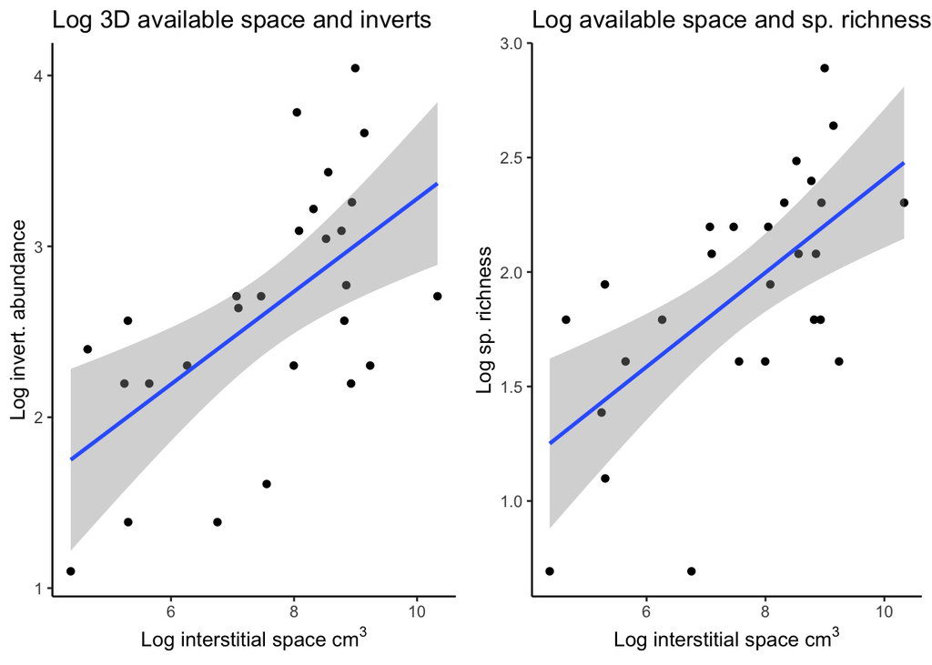

```r
#Create graphs of log transformed invertebrate abundance
log_cafi_space <- ggplot(cafi_coral, aes(x=log_interstitial_space, y=log_num_cafi))+
  geom_point()+
  geom_smooth(method = lm, se=TRUE)+
  theme_classic()+
  #facet_wrap(~branch)+
  labs(y="Log invert. abundance", x= expression(paste("Log interstitial space cm"^{3})), title = "Log 3D available space and inverts")

log_space_rich <- ggplot(cafi_coral, aes(x=log_interstitial_space, y=log_cafi_richness))+
  geom_point()+
  geom_smooth(method = lm, se=TRUE)+
  theme_classic()+
  #facet_wrap(~branch)+
  labs(y="Log sp. richness", x= expression(paste("Log interstitial space cm"^{3})), title = "Log available space and sp. richness")

fig2 <- ggarrange(log_cafi_space, log_space_rich,
                     ncol = 2, nrow = 1) #combines all graphs
fig2
```

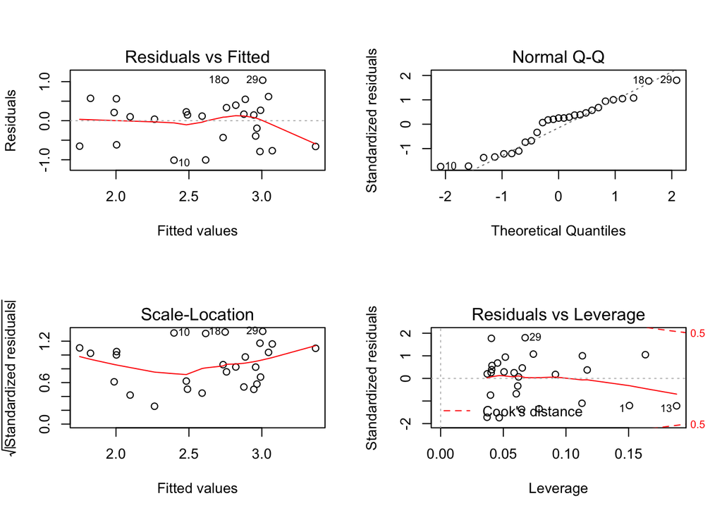

```r
#Residuals for log transformed data
log_lm_space <- lm(log_num_cafi~log_interstitial_space, data=cafi_coral)
par(mfrow=c(2,2))
plot(log_lm_space)
```

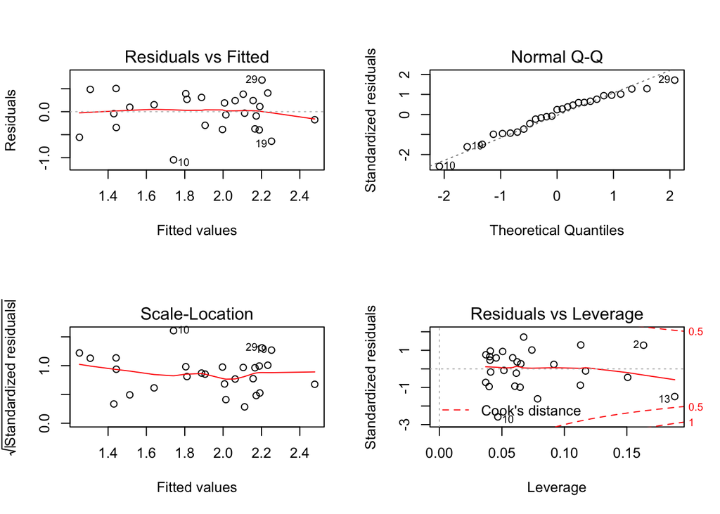

```r
par(mfrow=c(1,1))

log_lm_rich <- lm(log_cafi_richness~log_interstitial_space, data=cafi_coral)
par(mfrow=c(2,2))
plot(log_lm_rich)
```

```r
par(mfrow=c(1,1))
```

```r
#HTML table from regression results
pl <- c(
  '(Intercept)' = "Intercept",
  log_interstitial_space = "Log interstitial space"
)
tab_model(log_lm_space, log_lm_rich,
          pred.labels = pl,
          dv.labels = c("Log invertebrate abundance", "Log species richness"))
```

|  | Log invertebrate abundance |  |  | Log species richness |  |  |
| --- | --- | --- | --- | --- | --- | --- |
| Predictors | Estimates | CI | p | Estimates | CI | p |
| Intercept | 0.57 | -0.59 – 1.72 | 0.323 | 0.35 | -0.45 – 1.16 | 0.377 |
| Log interstitial space | 0.27 | 0.12 – 0.42 | **0.001** | 0.21 | 0.10 – 0.31 | **<0.001** |
| Observations | 27 |  |  | 27 |  |  |
| R<sup>2</sup> / R<sup>2</sup> adjusted | 0.359 / 0.333 |  |  | 0.399 / 0.374 |  |  |

Invertebrate abundance and species richness showed $p<0.05$ for both volume and interstitial space. We reject the null hypothesis that the slope of the regression line is equal to zero. The correlations for all four linear regressions were $R^2>30$

##### We will now fit a single variable Yi=β0+β1Xi+ϵi or multivariable linear model Y=β0+β1X1+β2X2+…+βnXn+ϵ to our data using different combinations of explanatory variables. Our response variable will be abundance of invertebrates. We will use AIC and R-squared values to determine the best fit model.

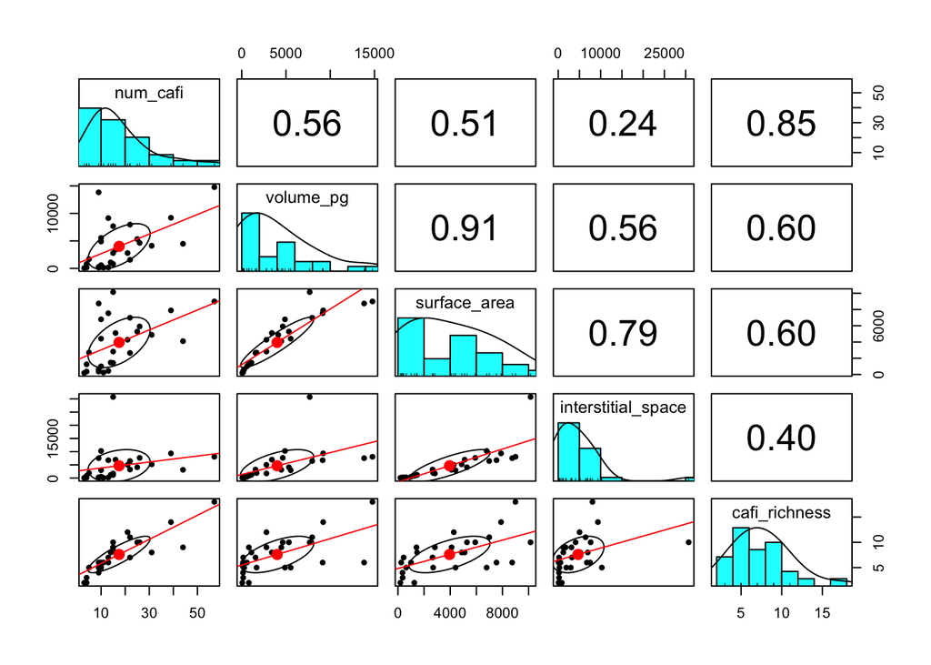

```r
#Visualize correlations between variables
cafi_coral2 <- cafi_coral %>%
  dplyr::select(num_cafi, volume_pg, surface_area, interstitial_space, cafi_richness)
pairs.panels(cafi_coral2, lm = TRUE, cor = T)
```

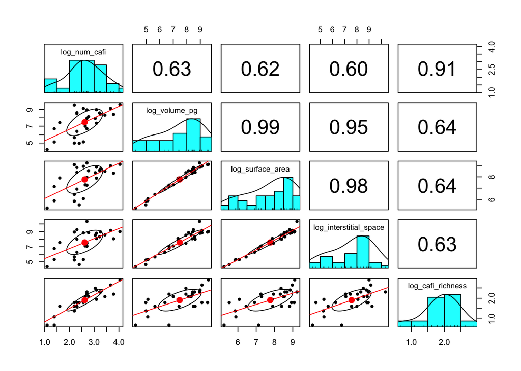

```r
log_cafi_coral <- cafi_coral %>%
  dplyr::select(log_num_cafi, log_volume_pg, log_surface_area, log_interstitial_space, log_cafi_richness)
pairs.panels(log_cafi_coral, lm = TRUE, cor = T)
```

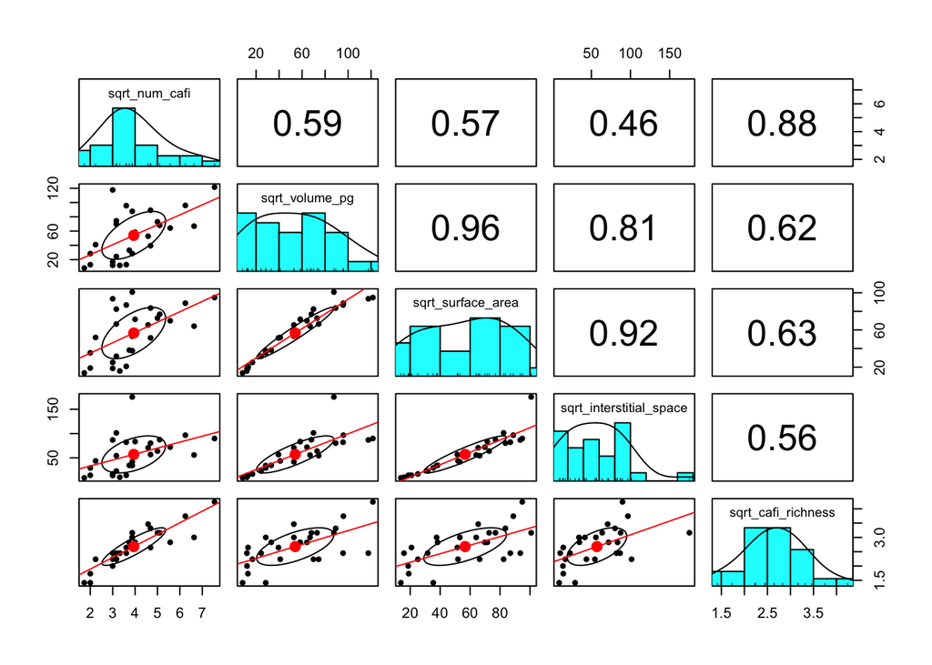

```r
sqrt_cafi_coral <- cafi_coral %>%
  dplyr::select(sqrt_num_cafi, sqrt_volume_pg, sqrt_surface_area, sqrt_interstitial_space, sqrt_cafi_richness)
pairs.panels(sqrt_cafi_coral, lm = TRUE, cor = T)
```

VIF>10 will be removed from the dataset

```r
sqrt_lm <- lm(sqrt_num_cafi~., data=sqrt_cafi_coral)

vif(sqrt_lm)
```

```
##          sqrt_volume_pg       sqrt_surface_area sqrt_interstitial_space
##               23.256512               52.389357               11.749198
##      sqrt_cafi_richness
##                1.668063
```

We will remove the sqrt transformed surface area measurement because of its high vif value and we will remove the sqrt transformed invertebrate richness since we will only be looking at coral measurements.

```r
lm2 <- lm(log_num_cafi~sqrt_volume_pg + log_interstitial_space, data=cafi_coral)
lm3 <- lm(log_num_cafi~sqrt_volume_pg, data=cafi_coral)
lm4 <- lm(log_num_cafi~log_interstitial_space, data=cafi_coral)

vif(lm2)
```

```
##         sqrt_volume_pg log_interstitial_space
##               4.127441               4.127441
```

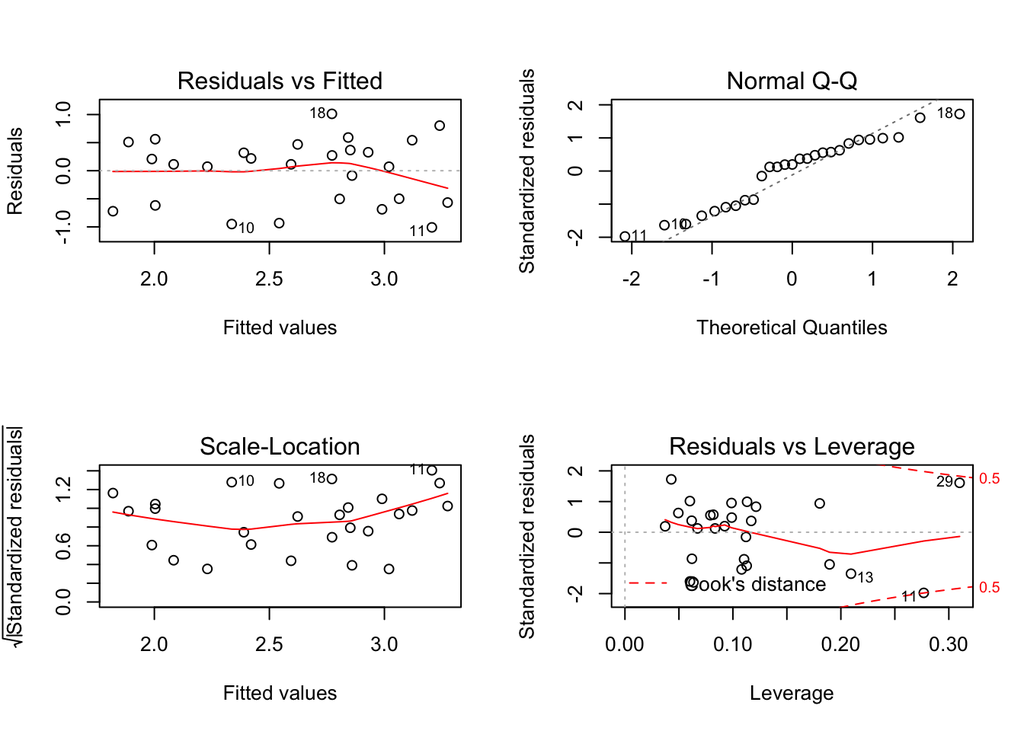

```r
res2=lm2$residuals

#Test normality assumption on residuals
par(mfrow=c(2,2))
plot(lm2)
```

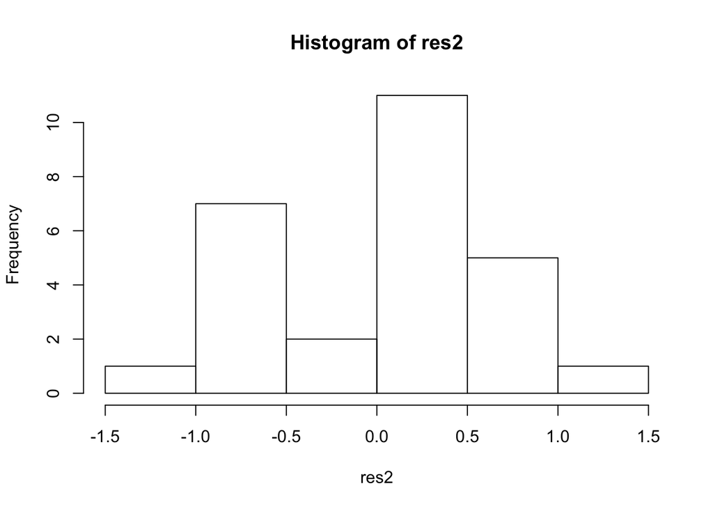

```r
par(mfrow=c(1,1))

hist(res2)
```

```r
shapiro.test(res2)
```

```
##
##  Shapiro-Wilk normality test
##
## data:  res2
## W = 0.93403, p-value = 0.08679
```

```r
#Data is FINALY! normal
```

```r
fullmodel <- lm(log_num_cafi~sqrt_volume_pg + log_interstitial_space, data=cafi_coral)
nullmodel <- lm(log_num_cafi~1, data=cafi_coral)

stepAIC(fullmodel, scope = c(upper = fullmodel, lower = nullmodel), direction = "both")
```

```
## Start:  AIC=-24.73
## log_num_cafi ~ sqrt_volume_pg + log_interstitial_space
##
##                          Df Sum of Sq    RSS     AIC
## - sqrt_volume_pg          1   0.22626 8.8772 -26.034
## - log_interstitial_space  1   0.46613 9.1170 -25.314
## <none>                                8.6509 -24.731
##
## Step:  AIC=-26.03
## log_num_cafi ~ log_interstitial_space
##
##                          Df Sum of Sq     RSS     AIC
## <none>                                 8.8772 -26.034
## - log_interstitial_space  1    4.9652 13.8423 -16.039
```

```
##
## Call:
## lm(formula = log_num_cafi ~ log_interstitial_space, data = cafi_coral)
##
## Coefficients:
##            (Intercept)  log_interstitial_space
##                 0.5656                  0.2713
```

```r
#Code chunk pulled from Lab 8, EEMB 146 Biometry
#calculate AIC of each model
result <- AIC(lm4,lm3,lm2) #create dataframe

#add other metrics to table
models <- list(lm4,lm3,lm2)
result$BIC <- sapply(models, BIC) #add a column for BIC to the results

model_summary <- lapply(models, summary)

#for loop
for(i in 1:length(models)){ #creates a variable i that starts with the value i=1
  result$rsq[i] <- model_summary[[i]]$r.squared #assign the rsq value from model i to the i'th row of the column 'rsq' in the table 'results'
  result$adj_rsq[i] <- model_summary[[i]]$adj.r.squared #same for adjusted rsq
}

kable(result, digits = 2, align = "c")
```

|  | df | AIC | BIC | rsq | adj_rsq |
| --- | --- | --- | --- | --- | --- |
| lm4 | 3 | 52.59 | 56.48 | 0.36 | 0.33 |
| lm3 | 3 | 53.31 | 57.20 | 0.34 | 0.32 |
| lm2 | 4 | 53.89 | 59.08 | 0.38 | 0.32 |

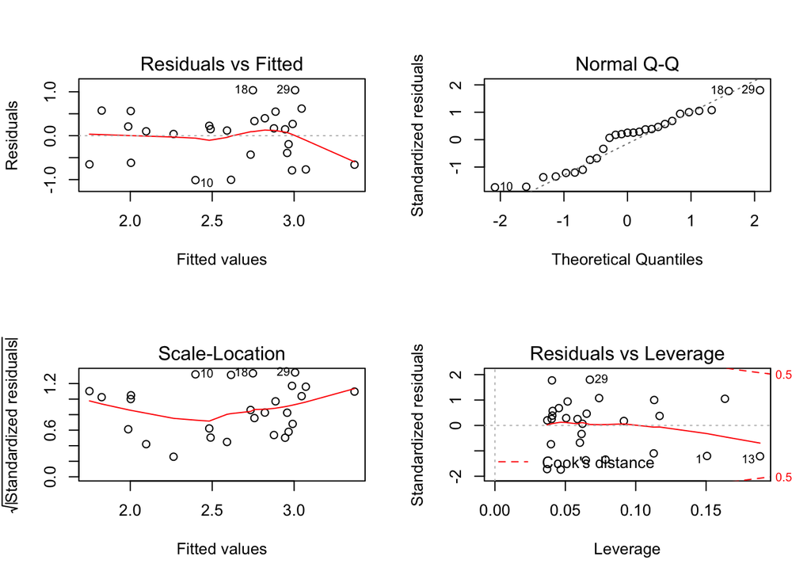

```r
final_res=lm4$residuals

#Test normality assumption on residuals
par(mfrow=c(2,2))
plot(lm4)
```

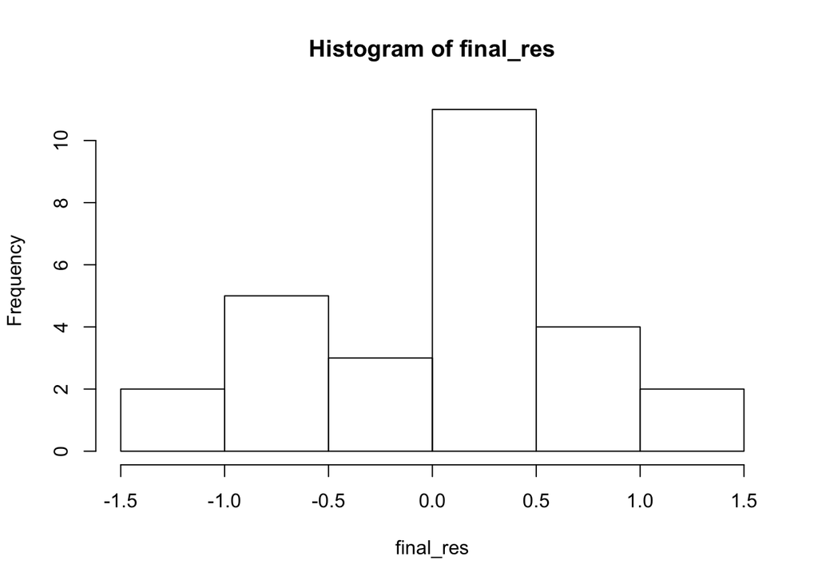

```r
par(mfrow=c(1,1))

hist(final_res)
```

```r
shapiro.test(final_res)
```

```
##
##  Shapiro-Wilk normality test
##
## data:  final_res
## W = 0.94813, p-value = 0.1931
```

```r
#Data is FINALY! normal
```